# Available samples from refine.bio

Sehyun Oh

2020-12-06

# 1 Information on training datasets

`studyMeta.tsv` table is available through `GenomicSuperSignature` package. In this table, we summarized the details on GenomicSuperSignature models and their training datasets. More detail is described below.

```r
extdata <- system.file("extdata", package = "GenomicSuperSignature")
studyMeta <- read.table(file.path(extdata, "studyMeta.tsv"))
head(studyMeta)
```

```
##   studyName downloaded metadata imported PCAmodel_677 PCAmodel_1399
## 2 DRP000425          4        4    FALSE        FALSE         FALSE
## 3 DRP000464          8        8    FALSE        FALSE         FALSE
## 4 DRP000499         21       21     TRUE        FALSE          TRUE
## 5 DRP000527          2        4    FALSE        FALSE         FALSE
## 6 DRP000665          7        7    FALSE        FALSE         FALSE
## 7 DRP000929          4        4    FALSE        FALSE         FALSE
##   PCAmodel_536
## 2        FALSE
## 3        FALSE
## 4        FALSE
## 5        FALSE
## 6        FALSE
## 7        FALSE
##                                                                                                                                                                     title
## 2                                                                                                           Homo sapiens T24 human bladder cancer cell line Transcriptome
## 3 pre-miRNA profiles obtained through application of locked nucleic acids reveals complex 5’/3’ arm variation including concomitant cleavage and polyuridylation patterns
## 4                                                                                                                      Homo sapiens strain:Human ICESeq Genome sequencing
## 5                                                                                                      RNA sequencing of wild-type or mutant U2AF35 transduced HeLa Cells
## 6                                                                                                             Global transcriptional response against glucose deprivation
## 7                                                                  Human inactive X chromosome is compacted through a polycomb-independent SMCHD1-HBiX1 pathway [RNA-seq]
```

# 2 Available datasets

## 2.1 From metadata

`aggregated_metadata.json` is downloaded along with the dataset we downloaded from [refine.bio](https://www.refine.bio/). We collect the number of samples per study based on this metadata.

```r
data.dir <- system.file("extdata", package = "GenomicSuperSignaturePaper")
meta_json <- jsonlite::fromJSON(file.path(data.dir,
                                          "aggregated_metadata.json"))
experiments <- meta_json[[2]]   # experiments
```

```r
studies <- list()
for (i in seq_along(experiments)) {
  studies <- append(studies, list(experiments[[i]]$sample_accession_codes))
  names(studies)[i] <- names(experiments)[i]
}

sampleNum <- sapply(studies, function(x) length(x))
```

## 2.2 Downloaded samples

I summarized the number of samples based on `aggregated_metadata.json` under `metadata` column and the number of actually downloaded `_quant.sf` sample files under `downloaded` column in a data frame, `studyMeta`.

```r
# download.dir <- "path/to/download/directory"
dirNames <- list.files(download.dir)

ind_rm <- which(dirNames %in%
                  c("aggregated_metadata.json", "README.md", "LICENSE.TXT"))
if (length(ind_rm) != 0) {dirNames <- dirNames[-ind_rm]}
length(dirNames) # 6457 studies were downloaded

studyMeta <- as.data.frame(matrix(NA, nrow = length(dirNames), ncol = 3))
colnames(studyMeta) <- c("studyName", "downloaded", "metadata")
studyMeta$studyName <- dirNames

for (i in seq_along(dirNames)) {
  dir_path <- file.path(download.dir, dirNames[i])

  ## actually downloaded samples
  ind1 <- which(studyMeta$studyName == dirNames[i])
  studyMeta$downloaded[ind1] <- grep("_quant.sf",
                                     list.files(dir_path)) %>% length

  ## availalbe samples based on metadata
  ind2 <- which(names(sampleNum) == dirNames[i])
  studyMeta$metadata[ind2] <- sampleNum[ind2]
}
```

## 2.3 Imported samples

The number samples succesfully imported by `tximport::tximport`

```r
studyNames <- studyMeta$studyName
importedFiles <- c()

for (i in seq_along(studyNames)) {
  out.path <- file.path(download.dir2, studyNames[i])
  fname <- file.path(out.path, paste0(studyNames[i], ".rds"))
  if (file.exists(fname)) {
    importedFiles <- c(importedFiles, studyNames[i])
  }
}

# 1399 studies > 20 samples were successfully tximport-ed
length(importedFiles)
```

```r
imported_ind <- which(studyMeta$studyName %in% importedFiles)
studyMeta$imported <- FALSE
studyMeta$imported[imported_ind] <- TRUE
```

## 2.4 Title of the studies

```r
for (i in seq_along(experiments)) {
  title <- experiments[[i]]$title
  studyMeta$title[i] <- title
}
```

# 3 Compare

```r
## Cases where all the available samples (based on metadata) were downloaded
sum(studyMeta$downloaded == studyMeta$metadata)
```

```
## [1] 3135
```

```r
## The number of studies with more than 100 samples:
## Actually downloaded vs. expected by metadata
sum(studyMeta$downloaded > 100)
```

```
## [1] 0
```

```r
sum(studyMeta$metadata > 100)
```

```
## [1] 426
```

## 3.1 Sample availability in histogram

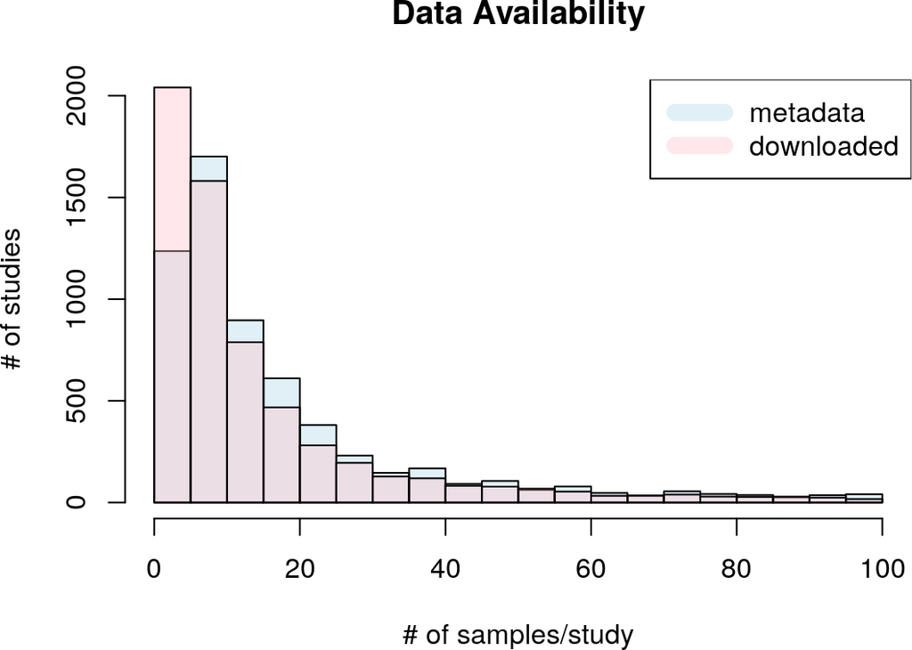

## 3.2 Example

Example study, `SRP152576`:  
- 13,127 samples are available based on `aggregated_metadata.json`.  
- No sample is available based on [refine.bio](https://www.refine.bio/) webpage.  
- 100 samples are actually downloaded.  
- 3,927 samples are available based on `metadata_SRP152576.csv`.

```r
ind <- which.max(studyMeta$metadata)
studyMeta[ind,]
```

```
##      studyName downloaded metadata imported PCAmodel_677 PCAmodel_1399
## 5531 SRP152576        100    13127     TRUE        FALSE          TRUE
##      PCAmodel_536
## 5531        FALSE
##                                                                                title
## 5531 In vivo molecular signatures of severe dengue infection revealed by viscRNA-Seq
```

```r
file_dir <- file.path(download.dir, studyMeta$studyName[ind])
fname <- paste0("metadata_", studyMeta$studyName[ind], ".tsv")
sampleMeta <- read.table(file.path(file_dir, fname), header = TRUE, sep = "\t")
dim(sampleMeta)
```

```
## [1] 3927   19
```

```r
head(sampleMeta, 3)
```

```
##   refinebio_accession_code experiment_accession refinebio_age
## 1               SRR7481117            SRP152576            14
## 2               SRR7480712            SRP152576            14
## 3               SRR7483223            SRP152576            31
##   refinebio_cell_line refinebio_compound refinebio_disease
## 1                  NA                 NA                NA
## 2                  NA                 NA                NA
## 3                  NA                 NA                NA
##   refinebio_disease_stage refinebio_genetic_information refinebio_organism
## 1                      NA                            NA       HOMO_SAPIENS
## 2                      NA                            NA       HOMO_SAPIENS
## 3                      NA                            NA       HOMO_SAPIENS
##         refinebio_platform refinebio_race refinebio_sex
## 1 NextSeq 500 (NextSeq500)             NA          male
## 2 NextSeq 500 (NextSeq500)             NA          male
## 3 NextSeq 500 (NextSeq500)             NA        female
##   refinebio_source_archive_url refinebio_source_database
## 1                           NA                       SRA
## 2                           NA                       SRA
## 3                           NA                       SRA
##   refinebio_specimen_part refinebio_subject refinebio_time refinebio_title
## 1                   blood     blood (pbmcs)             NA  1001701103_E10
## 2                   blood     blood (pbmcs)             NA  1001701101_C19
## 3                   blood     blood (pbmcs)             NA  1001701401_P23
##   refinebio_treatment
## 1                  NA
## 2                  NA
## 3                  NA
```

# 4 Studies used for model buildling

## 4.1 PCAmodel_677

`studies_with_error.csv` file contains the sample names that were failed to be downloaded/imported when I tried to use studies > 50 samples based on the metadata. You can find more documentation on this under `Methods/model_building`.

```r
## Name of studies that tximport failed due to malformed quant.sf
# gsig.dir <- "path/to/tximport/directory"
errors <- read.table(file.path(gsig.dir, "studies_with_error.csv"))
studies.errors <- gsub("ERROR with study ", "", errors$V1) %>%
  stringr::str_split(., " :") %>%
  sapply(., function(x) unlist(x)[1])

## Studies with more than 20 downloaded samples
# lib.dir <- "path/to/GenomicSuperSignatureLibrary"
dat <- readRDS(file.path(lib.dir, "allZ.rds"))
final <- gsub(".PC.*$", "", colnames(dat)) %>% unique   # 677 studies
ind_677 <- which(studyMeta$studyName %in% final)

studyMeta$PCAmodel_677 <- FALSE
studyMeta$PCAmodel_677[ind_677] <- TRUE
```

## 4.2 PCAmodel_1399

All the studies that have more than 20 successfully imported samples. So, it’s practically same as `imported` column.

```r
studyMeta$PCAmodel_1399 <- studyMeta$imported
```

## 4.3 PCAmodel_536

These 536 studies meet the criteria, > 50 (downloaded) and <1000 (metadata) samples per study. Also, any study with “Single-Cell Analysis” MeSH term was removed.

```r
mesh <- readRDS(file.path(extdata, "MeSH_terms_1399refinebio.rds"))
sc <- which(mesh$name %in% "Single-Cell Analysis")
sc_studies <- mesh$identifier[sc]   # single-cell associated studies to exclude

sc_ind <- which(studyMeta$studyName %in% sc_studies)
sn_ind <- which(studyMeta$downloaded > 50 &
                  studyMeta$metadata < 1000 &
                  studyMeta$imported == "TRUE")
ind_536 <- setdiff(sn_ind, sc_ind)

studyMeta$PCAmodel_536 <- FALSE
studyMeta$PCAmodel_536[ind_536] <- TRUE
```

# 5 Compare to multiPLIER training datasets

```r
## Training data used for GenomicSuperSignature
res <- readRDS("accessions.rds")

## Training data used for multiPLIER
recount2 <- read.table("https://raw.githubusercontent.com/greenelab/multi-plier/master/data/sample_info/recount2_srr_srs_srp.tsv", header = TRUE)

head(res, 3)
```

```
##         run     study
## 1 DRR006374 DRP000987
## 2 DRR006375 DRP000987
## 3 DRR006376 DRP000987
```

```r
head(recount2, 3)
```

```
##         run     study    sample
## 1 SRR013549 SRP000599 SRS002125
## 2 SRR013550 SRP000599 SRS002126
## 3 SRR013551 SRP000599 SRS002127
```

1. multiPLIER used 37027 unique runs from 1466 studies.
2. GenomicSuperSignature used 44890 unique runs from 536 studies.
3. There are 6839 overlapping runs from 87 studies used for both models.